# acNMF Method (v1.0.0)

Rich Chapple

2023-04-11

## Getting Started

### Splitting Data

The matrix must first be split into two roughly equal parts (referred to interchangeably as splits), such that approximately equal numbers of cells are contained in each split.

#### Load data and split

```r
library(Seurat)
library(SeuratDisk)
```

```r
set.seed(37645)
data <- readRDS("cNMF_simulated.RDS")
data <- as.data.frame(data)
dim(data)
```

```
## [1] 15000 25000
```

Randomly sample (with substitution) to generate a binary vector, then subset the original data to obtain two roughly equal splits.

```r
dummy_sep <- rbinom(nrow(data), 1, 0.5)
split0 <- data[dummy_sep == 0, ]
split1 <- data[dummy_sep == 1, ]

dim(split0)
```

```
## [1]  7516 25000
```

```r
dim(split1)
```

```
## [1]  7484 25000
```

#### Convert to H5AD

```r
split0 <- t(as.matrix(split0))
split1 <- t(as.matrix(split1))

s0 <- CreateSeuratObject(counts = split0)
s1 <- CreateSeuratObject(counts = split1)

SaveH5Seurat(s0, filename = "cnmf_input_benchmark_split0.h5Seurat")
SaveH5Seurat(s1, filename = "cnmf_input_benchmark_split1.h5Seurat")

Convert("cnmf_input_benchmark_split0.h5Seurat", dest = "h5ad", assay = "RNA")
Convert("cnmf_input_benchmark_split1.h5Seurat", dest = "h5ad", assay = "RNA")
```

## Running cNMF on Individual Splits

Run cNMF on each file generated above. This needs to be performed over a range of ranks. The following python code was used on split0.

```python
import csv
import os
import pandas as pd
import numpy as np
from scipy.io import mmread
import scipy.sparse as sp
import matplotlib.pyplot as plt
import scanpy as sc
from IPython.display import Image

np.random.seed(14)

########################
#Set cNMF run parameters
########################

numiter = 200
numhvgenes = 2000

K = ' '.join([str(i) for i in range(2,61)] + [str(i) for i in range(70,210,10)])
K_int = [int(i) for i in K.split()]

numworkers = numiter*len(K_int)

output_directory = "/<path>/<to>/<output_dir>/"
run_name = 'cNMF_split0'

countfn = "cnmf_input_benchmark_split0.h5ad"

seed = 14

###############################
#Set up directories for LSF i/o
###############################

logdir = os.getcwd() + '/split0_logdir'
os.system('mkdir ' + logdir)
factorize_dir = logdir + '/factorize'
os.system('mkdir ' + factorize_dir)
combine_dir = logdir + '/combine'
os.system('mkdir ' + combine_dir)
consensus_dir = logdir + '/consensus'
os.system('mkdir ' + consensus_dir)

##############
#Preprocessing
##############

prepare_cmd = 'python /home/rchapple/software/cNMF/cnmf_v2.0.py prepare --output-dir %s --name %s -c %s -k %s --n-iter %d --total-workers %d --seed %d --numgenes %d --beta-loss frobenius' % (output_directory, run_name, countfn, K, numiter, numworkers, seed, numhvgenes)
print('Prepare command assuming parallelization with %d tasks:\n%s' % (numworkers, prepare_cmd))
os.system(prepare_cmd)

##############
#Factorization
##############

worker_index = ' '.join([str(x) for x in range(numworkers)])

#Set up the job submission array
#Each job runs all iterations of NMF for each rank in one instance of opening the cNMF_v2.0.py script
#The number of jobs that get submitted to HPC are equivalent to the number of ranks

start = [int(i) for i in range(0, numworkers-1, numiter)]
end = [int(i) for i in range(numiter-1, numworkers, numiter)]
nmf_job_data = {'K':pd.Series(K_int), 'Start':pd.Series(start), 'End':pd.Series(end)}
nmf_job_submission = pd.DataFrame(nmf_job_data)

for x in nmf_job_submission.index:
    factorize_cmd = "bsub -P RC -J split0_factorize -R \"span[hosts=1] rusage[mem=10GB]\" -oo %s -eo %s 'python /home/rchapple/software/cNMF/cnmf_v2.0.py factorize --output-dir %s --name %s --jobstart %d --jobend %d'" % (factorize_dir, factorize_dir, output_directory, run_name, nmf_job_submission['Start'][x], nmf_job_submission['End'][x])
    print('Factorize command to run factorizations for rank = %d across all iterations' % (nmf_job_submission['K'][x]))
    os.system(factorize_cmd)

wait = "bwait -w 'ended(split0_factorize)'"
os.system(wait)

#################################
#Combine factorization replicates
#################################

combine_cmd = "bsub -P RC -J split0_combine -R\"rusage[mem=400GB]\" -q large_mem -oo %s -eo %s 'python /home/rchapple/software/cNMF/cnmf_v2.0.py combine --output-dir %s --name %s'" % (combine_dir, combine_dir, output_directory, run_name)
print(combine_cmd)
print('\n')
os.system(combine_cmd)

wait_combine = "bwait -w 'ended(split0_combine)'"
os.system(wait_combine)


##########################################################
#Cluster and plot consensus programs and KNN outlier plots
##########################################################

from itertools import chain

density_threshold = 2.00

for x in chain(range(2,61), range(70,210,10)):
    selected_K = x
    print("Selected_K =", selected_K, "\n")
    consensus_cmd = "bsub -P RC -J split0_consensus -R\"rusage[mem=400GB]\" -q large_mem -oo %s -eo %s 'python /home/rchapple/software/cNMF/cnmf_v2.0.py consensus --output-dir %s --name %s --local-density-threshold %.2f --components %d --show-clustering'" % (consensus_dir, consensus_dir, output_directory, run_name, density_threshold, selected_K)
    print('Consensus command for K=%d:\n%s' % (selected_K, consensus_cmd))
    os.system(consensus_cmd)

density_threshold_str = ('%.2f' % density_threshold).replace('.', '_')

#Outlier filtering

density_threshold = 0.10

for x in chain(range(2,61), range(70,210,10)):
    selected_K = x
    print("Selected_K =", selected_K, "\n")
    consensus_cmd = "bsub -P RC -J split0_consensus_outlier -R\"rusage[mem=400GB]\" -q large_mem -oo %s -eo %s 'python /home/rchapple/software/cNMF/cnmf_v2.0.py consensus --output-dir %s --name %s --local-density-threshold %.2f --components %d --show-clustering'" % (consensus_dir, consensus_dir, output_directory, run_name, density_threshold, selected_K)
    print('Consensus command for K=%d:\n%s' % (selected_K, consensus_cmd))
    os.system(consensus_cmd)

density_threshold_str = ('%.2f' % density_threshold).replace('.', '_')
```

## Post-cNMF Comparison of Each Data Split

Next, we evaluate (for each rank) the similarity of the two data splits. The Jaccard similarity index is calculated, and significant GEPs between the splits are represented as node pairs in a network graph. Community detection on the underlying graph is calculated, and recorded.

#### SplitStats function

```r
library(jaccard)
library(igraph)
library(vroom)

set.seed(1234)

#This function computes the Jaccard index and significance test for all programs in each benchmark split
#Once this is completed, a network graph is built using igraph package
#Community detection of the network graph is then calculated using betweeness scores

calcSplitStats <- function(split0, split1, k, jval){
    print("calcSplitStats")
    # for each row of split0, compare it to every row of split1
    jaccardInd <- numeric()
    jaccardIndPs <- numeric()

    for(i in 1:ncol(split0)){
        for(j in 1:ncol(split1)){
            GEP_split0 = as.numeric(rank(-split0[, i]) < jval)
            GEP_split1 = as.numeric(rank(-split1[, j]) < jval)
            jaccardTest <- jaccard.test.mca(GEP_split0, GEP_split1)
            jaccardInd <- c(jaccardInd, jaccardTest$statistics)
            jaccardIndPs <- c(jaccardIndPs, jaccardTest$pvalue)
        }
    }

    # Calculate FWERs
    k <- as.numeric(k)
    fwerJaccard <- p.adjust(jaccardIndPs, method="bonferroni")
    fwerJaccard <- t(matrix(fwerJaccard, nrow = k, ncol = k))

    # Calculate number of significant findings.
    sigFwerJaccard <- which(fwerJaccard < 0.05, arr.ind = T)

    #Calculate community number
    if(nrow(sigFwerJaccard) > 0){
        community.df <- as.data.frame(sigFwerJaccard)
        community.df$row <- paste0("Split0_GEP", community.df$row)
        community.df$col <- paste0("Split1_GEP", community.df$col)
        community.graph <- graph_from_data_frame(community.df, directed = F)
        ceb <- cluster_edge_betweenness(community.graph)
        community_number <- length(communities(ceb))
    }else{
        community_number <- 0
    }
    return(list(jaccardIndPs=jaccardIndPs, jaccardInd=jaccardInd, sigFwerJaccard=sigFwerJaccard, jaccard.com=community_number))
}
```

#### Calculating Jaccard similarity index for a range of Jaccard values

```r
ranks = c(seq(2,60), seq(70,200,10))
data.dir <- "/<path>/<to>/<cNMF_output>"
jaccard.val <- seq(10,100,10)

for(k in ranks){
  #Results list
  #Gets written to RDS file at end of R script
  jaccardtest_results <- list()

  #Read in NMF gene spectra scores
  print(paste0("Rank: ", k))
  split0 <- t(vroom(file = paste0(data.dir, "cNMF_split0/cNMF_split0.gene_spectra_score.k_", k, ".dt_0_10.txt"), col_select = c(-...1), show_col_types = FALSE))
  split1 <- t(vroom(file = paste0(data.dir, "cNMF_split1/cNMF_split1.gene_spectra_score.k_", k, ".dt_0_10.txt"), col_select = c(-...1), show_col_types = FALSE))

#Compute jaccard index for different jaccard lengths
  for(jval in jaccard.val){
      print(paste0("Jaccard Length: ", jval))
      splitstatlist <- list()
      splitstatlist <- calcSplitStats(split0, split1, k, jval)
      jval.name <- as.character(jval)
      jaccardtest_results[[jval.name]] <- splitstatlist
  }

  #This list contains the computations across all jaccard lengths for the rank provided on the command line
  saveRDS(jaccardtest_results, file = paste0("jaccardtest_results_K", k, ".RDS"))
}
```

## Plotting Results

```r
library(ggplot2)
library(dplyr)

simdata.dir <- "/<path>/<to>/<jaccardtest_results>/"
sim.df <- NULL

jaccardtest_results <- list()

for(k in ranks){
  splitstats <- readRDS(file = paste0(simdata.dir, seed, "/results/jaccardtest_results_K", k, ".RDS"))
  jaccardtest_results[[k]] <- splitstats
}

jaccard.val <- as.character(jaccard.val)

#for plotting
com.df <- NULL

for(x in ranks){
  u <- NULL
  for(y in jaccard.val){
    u <- c(u, jaccardtest_results[[x]][[y]][["jaccard.com"]])
  }
  u <- cbind(u, x)
  u <- data.frame(u, jaccard.val)
  com.df <- rbind(com.df, u)
}

colnames(com.df) <- c("Community_Number", "Rank", "Jaccard_Length")

#rank on x axis
com.df$Rank <- as.integer(com.df$Rank)
com.df$Jaccard_Length <- as.character(com.df$Jaccard_Length)
com.df$Jaccard_Length <- factor(com.df$Jaccard_Length, levels = c("10", "20", "30", "40", "50", "60", "70", "80", "90", "100"))


sim_plot <- ggplot(com.df, aes(x=Rank,y=Community_Number, group = Jaccard_Length, color = Jaccard_Length)) +
                stat_smooth(method="loess", span=0.2, se=TRUE, aes(fill=Jaccard_Length), alpha=0.3) +
                theme_linedraw()
```

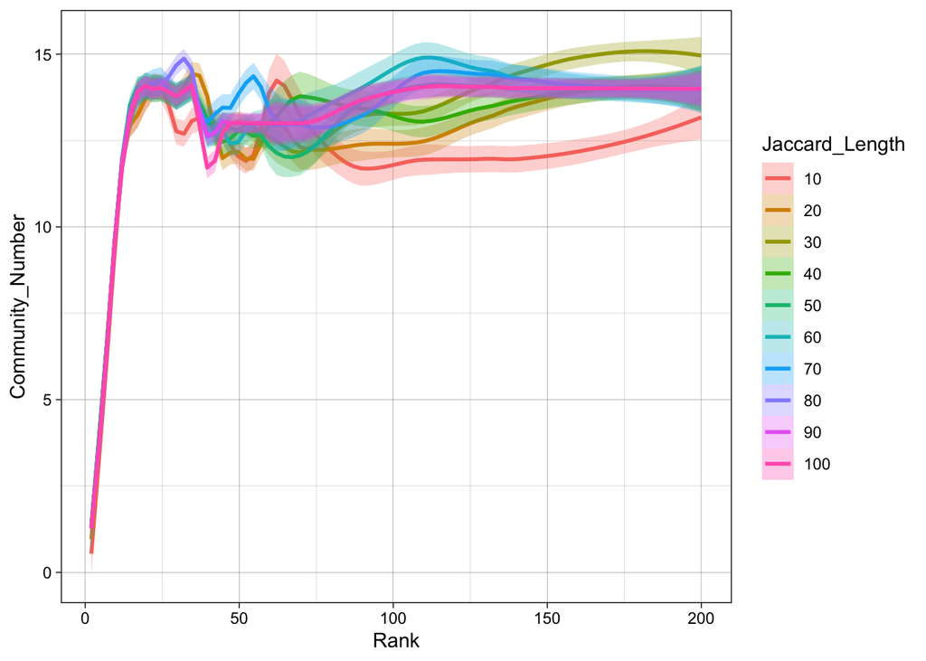

```r
sim_plot
```

This block of code evaluates which curve has the best inflection point

```r
devtools::install_github("ahasverus/elbow")
library(elbow)

jl.eval <- data.frame()

for(x in jaccard.val){
  x <- as.numeric(x)
  jl.df <- com.df %>% filter(Jaccard_Length == x)
  #Run a loess regression on JL data to smooth the curve
  sl <- jl.df %>% ggplot(aes(Rank, Community_Number))
                      + geom_point()
                      + geom_smooth(method = "loess", span = 0.3, method.args = list(degree = 1))
  gbuild <- ggplot_build(sl)
  elbow.df <- data.frame(X = gbuild$data[[2]]$x, Y = gbuild$data[[2]]$y)
  #Find inflection point
  ipoint <- elbow(data = elbow.df, plot = F)
  #Since the data was run on smoothed data, retreive the closest rank to the x intercept calculated by elbow package
  optimum.rank <- ranks[which.min(abs(ranks - ipoint$X_selected))]
  #Run linear regression on cost values (X values after inflection point) and determine slope
  ipoint.filtered <- ipoint$data %>% filter(X >= ipoint$X_selected)
  reg <- lm(ipoint.filtered$benefits ~ ipoint.filtered$X)
  jl.eval <- rbind(jl.eval, c(x, optimum.rank, reg$coefficients[2]))
}
```

The following plots were generated when the Jaccard length was set to 10

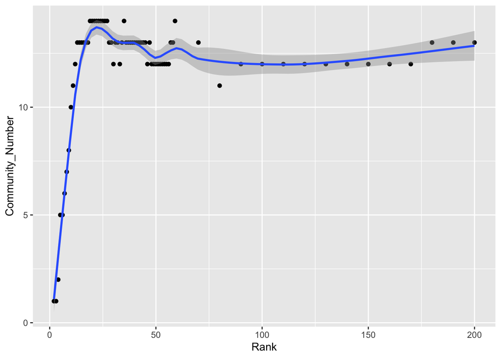

```r
sl
```

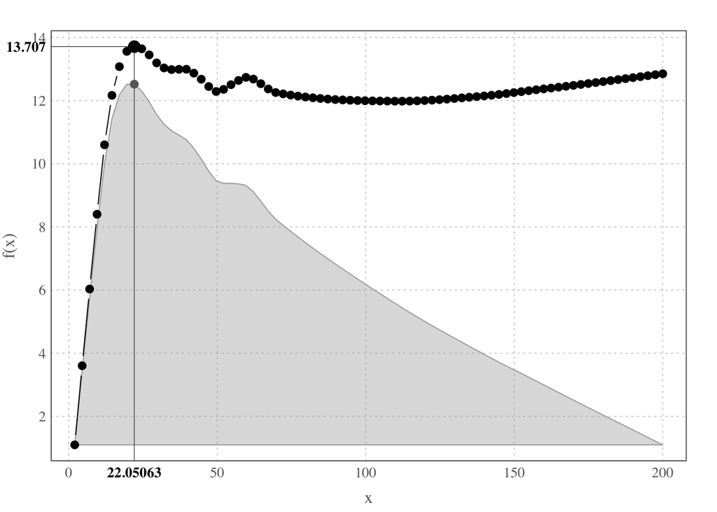

```
## $X_selected
## [1] 22.05063
##
## $data
##             X         Y constant  benefits
## 1    2.000000  1.098521    1.099  1.098521
## 2    4.506329  3.604137    1.247  3.455521
## 3    7.012658  6.032960    1.396  5.735521
## 4    9.518987  8.400256    1.545  7.953521
## 5   12.025316 10.597855    1.693 10.003521
## 6   14.531646 12.164626    1.842 11.421521
## 7   17.037975 13.074135    1.991 12.181521
## 8   19.544304 13.556808    2.140 12.515521
## 9   22.050633 13.707028    2.288 12.517521
## 10  24.556962 13.639138    2.437 12.300521
```

[output cut: 70 more lines]

```r
elbow(data=elbow.df)
```

This programmatically determines the most optimal parameters (rank and Jaccard length) for the dataset

```r
colnames(jl.eval) <- c("JL", "Rank", "Slope")
#This will determine which JL curve gives the steepest slope for the cost values
max.slope.params <- jl.eval %>% filter(JL == jl.eval$JL[jl.eval$Slope == min(jl.eval$Slope)])
comnum <- com.df %>% filter(Jaccard_Length == max.slope.params$JL & Rank == max.slope.params$Rank)
params <- as.data.frame(cbind(comnum$Community_Number, max.slope.params$Rank, max.slope.params$JL))
colnames(params) <- c("Community_Number", "Rank", "Jaccard_Length")

optimized.community.params[[<dataset.name>]] <- params

#Get the significant matches(indeces) from the Jaccard test

sig.labels <- as.data.frame(jaccardtest_results[[params$Rank]][[as.character(params$Jaccard_Length)]]$sigFwerJaccard)
sig.labels$row <- paste0("Split0_GEP", sig.labels$row)
sig.labels$col <- paste0("Split1_GEP", sig.labels$col)
com.labels[[<dataset.name>] <- sig.labels

saveRDS(optimized.community.params, file = "optimized_community_paramters.RDS")
saveRDS(com.labels, file = "community_labels.RDS")
```

Optimal parameters

```r
optimized_community_parameters
```

```
##   Community_Number Rank Jaccard_Length
## 1               14   22             10
```

Significant pairs of replicated GEPs across the splits

```r
com.labels
```

```
##             row          col
## 1  Split0_GEP10  Split1_GEP2
## 2  Split0_GEP13  Split1_GEP3
## 3   Split0_GEP2  Split1_GEP4
## 4  Split0_GEP14  Split1_GEP6
## 5  Split0_GEP15  Split1_GEP7
## 6   Split0_GEP4  Split1_GEP8
## 7  Split0_GEP21  Split1_GEP9
## 8  Split0_GEP16 Split1_GEP10
## 9   Split0_GEP8 Split1_GEP11
## 10  Split0_GEP1 Split1_GEP12
## 11 Split0_GEP12 Split1_GEP14
## 12  Split0_GEP5 Split1_GEP15
## 13  Split0_GEP6 Split1_GEP17
## 14  Split0_GEP9 Split1_GEP21
```